# Share modules in the private registry

- 8min
- |
- HCP Terraform
- Terraform

Publishing Workflow

Publishing Workflow

- Tag-based Publishing

HCP Terraform allows users to create and confidentially share infrastructure modules within an organization using the private registry. With Terraform Enterprise, the private registry allows you to share modules within or across organizations.

In this tutorial, you will share a module in the private registry that deploys an S3-backed webapp. Then you will use that module by referencing it in a root Terraform configuration. For this tutorial, you will fork and work with two sample repositories: one containing the module definition, and another with configuration code that uses the module.

## Prerequisites

To complete this tutorial, you will need:

- A GitHub account
- An HCP Terraform account. If you have not set up HCP Terraform yet, follow the Getting Started - HCP Terraform tutorial on creating a workspace.
- An AWS account [with IAM Access Keys](https://docs.aws.amazon.com/IAM/latest/UserGuide/id_credentials_access-keys.html#Using_CreateAccessKey)
- an HCP Terraform variable set configured with your AWS credentials.
- [OAuth Access to GitHub](https://developer.hashicorp.com/terraform/cloud-docs/vcs/github) configured. If you belong to an organization where you don't have permission to configure this access, you can create a new organization for this tutorial.

## Create the repository

Fork the [example repository](https://github.com/hashicorp-education/learn-private-module-aws-s3-webapp) for the webapp module.

Review the module configuration for the `s3-webapp` module. The repository looks similar to the directory structure below.

```
.
└──learn-private-module-aws-s3-webapp
  ├── main.tf
  ├── outputs.tf
  └── variables.tf
  └── assets
      └── index.html
```

The `variables.tf` file will define your HCP Terraform variables as inputs for the `aws_bucket` resource that Terraform will create. This module also contains the webapp assets as well as the `aws_s3_object` resource to upload your content to the S3 bucket resource.

Rename your forked repository. Go to the **Settings** tab of your forked repository. Under **Repository name**, rename your repository to `terraform-aws-s3-webapp`. When you publish a single module in a git repository, we recommend you follow the naming convention `terraform-<PROVIDER>-<NAME>` to make it easier for users to identify which module corresponds to which git repository.

[figure not shown]

## Import the module

Note

The Private Registry *requires* OAuth verification to GitHub. If you haven't already, follow the [OAuth instructions](https://developer.hashicorp.com/terraform/cloud-docs/vcs/github) before proceeding.

To create a Terraform module for your private registry, go to your organization's **Registry**, click the **Publish** dropdown, then select **Module**.

[figure not shown]

Choose the GitHub(Custom) VCS provider you configured and select the module repository named `terraform-aws-s3-webapp`.

Select the **Branch** module publishing type.

Set the **Branch Name** to `main`, the **Module Version** to `1.0.0`. Leave the **Source Directory** field. Use the **Branch Name** and **Source Directory** fields when the repository contains multiple modules, so that HCP Terraform can select which source files to import when you publish new releases. Refer to the [documentation on publishing modules](https://developer.hashicorp.com/terraform/cloud-docs/registry/publish-modules) for more information.

Click the **Next** button.

Once you have added your module, notice the **Usage Instructions** section. You will use these as the building blocks for your workspace configuration.

[figure not shown]

Tip

HCP Terraform **Standard** Edition lets you publish modules that users deploy without referencing them in Terraform configuration. Follow the Create and Use No-Code Modules tutorial to create a no-code ready module.

## Create a configuration that uses the module

Fork the [root configuration repository](https://github.com/hashicorp-education/learn-private-module-root). This repository will access the module you created and Terraform will use it to create infrastructure.

In a previous tutorial, you learned how to locally create a Terraform module, but now that your modules are stored in the cloud, your configuration will need to reflect the new location.

Your `main.tf` file in your root GitHub repository has the module reference to the private module you created in in HCP Terraform. You will need to replace `hashicorp-learn` with your own organization name.

```
terraform {
  required_providers {
    aws = {
      source  = "hashicorp/aws"
      version = "~> 4.0.0"
    }
  }
}

provider "aws" {
  region = var.region
}

module "s3-webapp" {
  source  = "app.terraform.io/hashicorp-learn/s3-webapp/aws"
  name   = var.name
  region = var.region
  prefix = var.prefix
  version = "1.0.0"
}
```

In this repository, you have a `variables.tf` file and an `outputs.tf` file as well.

The `variables.tf` file defines the variables that are required inputs into your module. Although you will enter these manually in the HCP Terraform web UI, it is still a good idea to have these in your root configuration so that other teammates understand the required inputs.

```
variable "region" {
  description = "This is the cloud hosting region where your webapp will be deployed."
}

variable "prefix" {
  description = "This is the environment your webapp will be prefixed with. dev, qa, or prod"
}

variable "name" {
  description = "Your name to attach to the webapp address"
}
```

HCP Terraform uses the `outputs.tf` file to display your module outputs as you run them in the web UI.

```
output "website_endpoint" {
  value = module.s3-webapp.endpoint
}
```

## Create a workspace for the configuration

In HCP Terraform, create a new workspace and choose your GitHub connection.

HCP Terraform will display a list of your GitHub repositories. You may need to filter by name to find and choose the your root configuration repository, called `learn-private-module-root`.

Leave the workspace name and advanced options unchanged, and click the **Create workspace** button to create the workspace.

Once your configuration is uploaded successfully, HCP Terraform will prompt you to **Configure Terraform variables**.

Set the region to `us-east-1`, the prefix to `dev-test`, and the name to your name. These variables correspond to the `variables.tf` file in your root module configuration and are necessary to create a unique S3 bucket name for your webapp. Then click **Save variables**.

[figure not shown]

HCP Terraform displays a success message. Click the **Go to workspace overview** button.

Note

This tutorial assumes that you are using a tutorial-specific HCP Terraform organization with a global variable set of your AWS credentials. Review the Create a Credential Variable Set for detailed guidance. If you are using a scoped variable set, [assign it to your new workspace](https://developer.hashicorp.com/terraform/cloud-docs/workspaces/variables/managing-variables#apply-or-remove-variable-sets-from-inside-a-workspace) now.

## Deploy the infrastructure

On the workspace overview page, drop down the **Actions** menu, and select **Start new run**.

[figure not shown]

The output in the HCP Terraform UI plan is similar to the output from a Terraform CLI plan and will detail the resources each module will create. Confirm the plan.

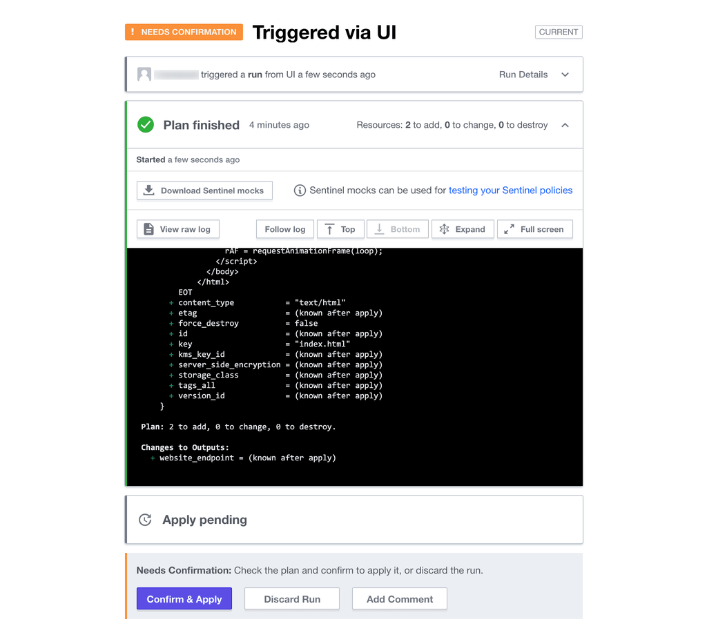

The apply output generates the resources as they are defined in the modules. Navigate to the `website_endpoint` address in a browser to test your deployment.

## Destroy your deployment

In the HCP Terraform UI for your workspace, open the **Settings** menu and choose **Destruction and Deletion**. Click the **Queue destroy plan** button and run a destroy plan against the infrastructure you created.

When Terraform prompts you, enter the workspace name to verify that you want to allow this plan to run. Click **Queue destroy plan** to start the run. When the plan finishes, click **Confirm & Apply** to clean up your deployment.

## Next Steps

In this tutorial, you:

1. Created and versioned a GitHub repository for use in the private registry
2. Imported a module into your organization's private registry.
3. Constructed a root module to consume modules from the private registry.

Learn more about finding and sharing modules:

- Read the documentation on the [private registry](https://developer.hashicorp.com/terraform/cloud-docs/registry).
- Follow the Create and Use No-Code Modules tutorial.
- In this tutorial, you published a single module, hosted in a single git repository. You can also publish [multiple modules](https://developer.hashicorp.com/terraform/cloud-docs/registry/publish-modules#enable-publishing-from-a-single-repository) from a single repository.

Previous

Object attributes

Next

Add from the public registry

© 2026 HashiCorp  
Licensed under the MPL 2.0 License.  
https://developer.hashicorp.com/terraform/tutorials/modules/module-private-registry-share?variants=module-workflow%3Abranch